# ANÁLISIS DE CORRESPONDENCIAS MÚLTIPLES

Wilson Sandoval Rodríguez

2024-02-22

## ANALISIS DE CORRESPONDENCIAS MULTIPLES (MCA)

El análisis de correspondencia múltiple (MCA) es una extensión del análisis de correspondencia simple para resumir y visualizar una tabla de datos que contiene más de dos variables categóricas. También puede verse como una generalización del análisis de componentes principales cuando las variables a analizar son categóricas en lugar de cuantitativas.

MCA se usa generalmente para analizar un conjunto de datos de una encuesta. El objetivo es identificar:

- Un grupo de personas con perfil similar en sus respuestas a las preguntas
- Las asociaciones entre categorías de variables

A continuacion, se va a calcular y visualizar análisis de correspondencias múltiples en el software $\mathrm{R}$ usando FactoMineR (para el análisis) y factoextra (para la visualización de datos).

```r
library(FactoMineR)
library(factoextra)
library(gplots)
library(corrplot)
library(dplyr)
```

```r
data("poison")
str(poison)
```

```
## 'data.frame':    55 obs. of  15 variables:
##  $ Age       : int  9 5 6 9 7 72 5 10 5 11 ...
##  $ Time      : int  22 0 16 0 14 9 16 8 20 12 ...
##  $ Sick      : Factor w/ 2 levels "Sick_n","Sick_y": 2 1 2 1 2 2 2 2 2 2 ...
##  $ Sex       : Factor w/ 2 levels "F","M": 1 1 1 1 2 2 1 1 2 2 ...
##  $ Nausea    : Factor w/ 2 levels "Nausea_n","Nausea_y": 2 1 1 1 1 1 1 2 2 1 ...
##  $ Vomiting  : Factor w/ 2 levels "Vomit_n","Vomit_y": 1 1 2 1 2 1 2 2 1 2 ...
##  $ Abdominals: Factor w/ 2 levels "Abdo_n","Abdo_y": 2 1 2 1 2 2 2 2 2 1 ...
##  $ Fever     : Factor w/ 2 levels "Fever_n","Fever_y": 2 1 2 1 2 2 2 2 2 2 ...
##  $ Diarrhae  : Factor w/ 2 levels "Diarrhea_n","Diarrhea_y": 2 1 2 1 2 2 2 2 2 2 ...
##  $ Potato    : Factor w/ 2 levels "Potato_n","Potato_y": 2 2 2 2 2 2 2 2 2 2 ...
##  $ Fish      : Factor w/ 2 levels "Fish_n","Fish_y": 2 2 2 2 2 1 2 2 2 2 ...
##  $ Mayo      : Factor w/ 2 levels "Mayo_n","Mayo_y": 2 2 2 1 2 2 2 2 2 2 ...
##  $ Courgette : Factor w/ 2 levels "Courg_n","Courg_y": 2 2 2 2 2 2 2 2 2 2 ...
##  $ Cheese    : Factor w/ 2 levels "Cheese_n","Cheese_y": 2 1 2 2 2 2 2 2 2 2 ...
##  $ Icecream  : Factor w/ 2 levels "Icecream_n","Icecream_y": 2 2 2 2 2 2 2 2 2 2 ...
```

```r
dim(poison)
```

```
## [1] 55 15
```

```r
write.csv2(poison, "poison1.csv")
```

```r
poison%>%DT::datatable()
```

|  | Age | Time | Sick | Sex | Nausea | Vomiting | Abdominals | Fever | Diarrhae | Potato | Fish | Mayo | Courgette | Cheese | Icecream |
| --- | --- | --- | --- | --- | --- | --- | --- | --- | --- | --- | --- | --- | --- | --- | --- |
| 1 | 9 | 22 | Sick_y | F | Nausea_y | Vomit_n | Abdo_y | Fever_y | Diarrhea_y | Potato_y | Fish_y | Mayo_y | Courg_y | Cheese_y | Icecream_y |
| 2 | 5 | 0 | Sick_n | F | Nausea_n | Vomit_n | Abdo_n | Fever_n | Diarrhea_n | Potato_y | Fish_y | Mayo_y | Courg_y | Cheese_n | Icecream_y |
| 3 | 6 | 16 | Sick_y | F | Nausea_n | Vomit_y | Abdo_y | Fever_y | Diarrhea_y | Potato_y | Fish_y | Mayo_y | Courg_y | Cheese_y | Icecream_y |
| 4 | 9 | 0 | Sick_n | F | Nausea_n | Vomit_n | Abdo_n | Fever_n | Diarrhea_n | Potato_y | Fish_y | Mayo_n | Courg_y | Cheese_y | Icecream_y |
| 5 | 7 | 14 | Sick_y | M | Nausea_n | Vomit_y | Abdo_y | Fever_y | Diarrhea_y | Potato_y | Fish_y | Mayo_y | Courg_y | Cheese_y | Icecream_y |
| 6 | 72 | 9 | Sick_y | M | Nausea_n | Vomit_n | Abdo_y | Fever_y | Diarrhea_y | Potato_y | Fish_n | Mayo_y | Courg_y | Cheese_y | Icecream_y |
| 7 | 5 | 16 | Sick_y | F | Nausea_n | Vomit_y | Abdo_y | Fever_y | Diarrhea_y | Potato_y | Fish_y | Mayo_y | Courg_y | Cheese_y | Icecream_y |
| 8 | 10 | 8 | Sick_y | F | Nausea_y | Vomit_y | Abdo_y | Fever_y | Diarrhea_y | Potato_y | Fish_y | Mayo_y | Courg_y | Cheese_y | Icecream_y |
| 9 | 5 | 20 | Sick_y | M | Nausea_y | Vomit_n | Abdo_y | Fever_y | Diarrhea_y | Potato_y | Fish_y | Mayo_y | Courg_y | Cheese_y | Icecream_y |
| 10 | 11 | 12 | Sick_y | M | Nausea_n | Vomit_y | Abdo_n | Fever_y | Diarrhea_y | Potato_y | Fish_y | Mayo_y | Courg_y | Cheese_y | Icecream_y |

[output cut: 45 more lines]

La data es resultado de una encuesta realizada a niños de primaria que sufrieron intoxicación alimentaria. Se les preguntó sobre sus síntomas y sobre lo que comían.

- Los datos contienen 55 filas (individuos)
- 15 columnas (variables).

Consideremos unicamente variables culitativas de los sintomas y comida consumida

```r
poison_active=poison[,5:15]
poison_active%>%DT::datatable()
```

|  | Nausea | Vomiting | Abdominals | Fever | Diarrhae | Potato | Fish | Mayo | Courgette | Cheese | Icecream |
| --- | --- | --- | --- | --- | --- | --- | --- | --- | --- | --- | --- |
| 1 | Nausea_y | Vomit_n | Abdo_y | Fever_y | Diarrhea_y | Potato_y | Fish_y | Mayo_y | Courg_y | Cheese_y | Icecream_y |
| 2 | Nausea_n | Vomit_n | Abdo_n | Fever_n | Diarrhea_n | Potato_y | Fish_y | Mayo_y | Courg_y | Cheese_n | Icecream_y |
| 3 | Nausea_n | Vomit_y | Abdo_y | Fever_y | Diarrhea_y | Potato_y | Fish_y | Mayo_y | Courg_y | Cheese_y | Icecream_y |
| 4 | Nausea_n | Vomit_n | Abdo_n | Fever_n | Diarrhea_n | Potato_y | Fish_y | Mayo_n | Courg_y | Cheese_y | Icecream_y |
| 5 | Nausea_n | Vomit_y | Abdo_y | Fever_y | Diarrhea_y | Potato_y | Fish_y | Mayo_y | Courg_y | Cheese_y | Icecream_y |
| 6 | Nausea_n | Vomit_n | Abdo_y | Fever_y | Diarrhea_y | Potato_y | Fish_n | Mayo_y | Courg_y | Cheese_y | Icecream_y |
| 7 | Nausea_n | Vomit_y | Abdo_y | Fever_y | Diarrhea_y | Potato_y | Fish_y | Mayo_y | Courg_y | Cheese_y | Icecream_y |
| 8 | Nausea_y | Vomit_y | Abdo_y | Fever_y | Diarrhea_y | Potato_y | Fish_y | Mayo_y | Courg_y | Cheese_y | Icecream_y |
| 9 | Nausea_y | Vomit_n | Abdo_y | Fever_y | Diarrhea_y | Potato_y | Fish_y | Mayo_y | Courg_y | Cheese_y | Icecream_y |
| 10 | Nausea_n | Vomit_y | Abdo_n | Fever_y | Diarrhea_y | Potato_y | Fish_y | Mayo_y | Courg_y | Cheese_y | Icecream_y |

[output cut: 45 more lines]

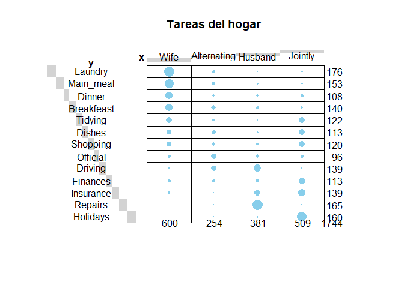

```r
balloonplot(as.table(t(as.matrix(housetasks))), label=F, main="Tareas del hogar")
```

observemos la frecuencia de los sintomas

```r
summary(poison_active[,1:4])
```

```
##       Nausea      Vomiting   Abdominals     Fever
##  Nausea_n:43   Vomit_n:33   Abdo_n:18   Fever_n:20
##  Nausea_y:12   Vomit_y:22   Abdo_y:37   Fever_y:35
```

observemos la frecuencias de la comida consumida

```r
summary(poison_active[,6:11])
```

```
##       Potato       Fish        Mayo      Courgette       Cheese
##  Potato_n: 3   Fish_n: 1   Mayo_n:10   Courg_n: 5   Cheese_n: 7
##  Potato_y:52   Fish_y:54   Mayo_y:45   Courg_y:50   Cheese_y:48
##        Icecream
##  Icecream_n: 4
##  Icecream_y:51
```

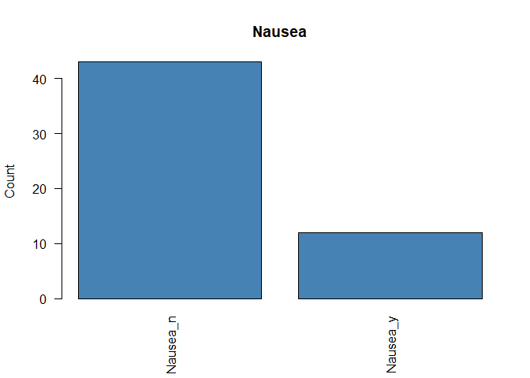

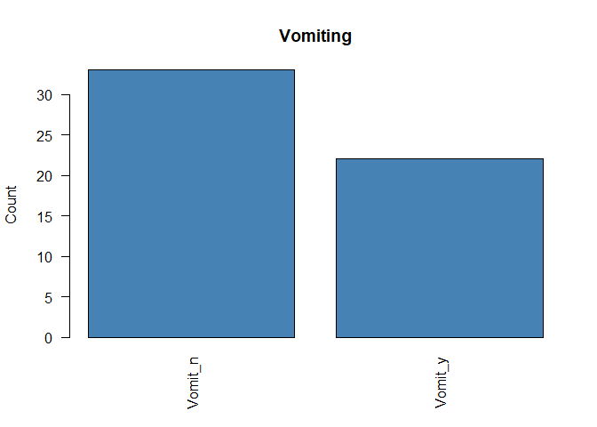

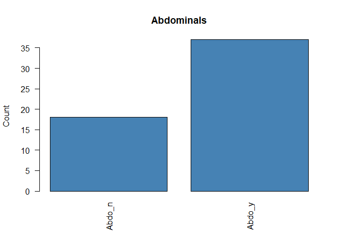

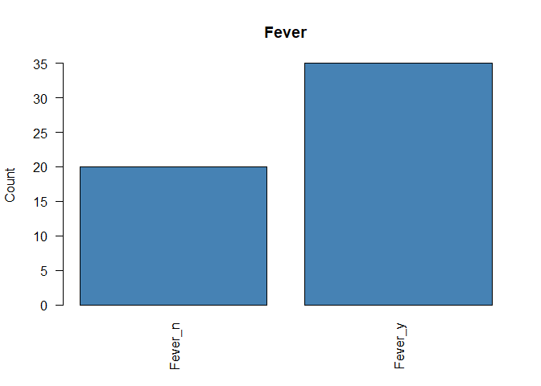

```r
for (i in 1:4) {
  plot(poison_active[, i], main=colnames(poison_active) [i],
        ylab ="Count", col="steelblue", las =2)
  }
```

## Tabla de contingencia nauseas vs los que consumieron mayoneasa

```r
table(poison_active[,c(1,8)])
```

```
##           Mayo
## Nausea     Mayo_n Mayo_y
##   Nausea_n     10     33
##   Nausea_y      0     12
```

## Tabla de contingencia nauseas vs los que consumieron mayonesa y vomito

```r
table(poison_active[,c(1,2,8)])
```

```
## , , Mayo = Mayo_n
##
##           Vomiting
## Nausea     Vomit_n Vomit_y
##   Nausea_n       9       1
##   Nausea_y       0       0
##
## , , Mayo = Mayo_y
##
##           Vomiting
## Nausea     Vomit_n Vomit_y
##   Nausea_n      19      14
##   Nausea_y       5       7
```

## Una forma más apropiada

Para observar todas las variables cualitativas en una sola tabla es usando la funcion Burt

```r
library("GDAtools")
```

```r
burt(poison_active)
```

```
##                     Nausea.Nausea_n Nausea.Nausea_y Vomiting.Vomit_n
## Nausea.Nausea_n                  43               0               28
## Nausea.Nausea_y                   0              12                5
## Vomiting.Vomit_n                 28               5               33
## Vomiting.Vomit_y                 15               7                0
## Abdominals.Abdo_n                18               0               17
## Abdominals.Abdo_y                25              12               16
## Fever.Fever_n                    19               1               18
## Fever.Fever_y                    24              11               15
## Diarrhae.Diarrhea_n              20               0               17
## Diarrhae.Diarrhea_y              23              12               16
## Potato.Potato_n                   1               2                3
## Potato.Potato_y                  42              10               30
## Fish.Fish_n                       1               0                1
## Fish.Fish_y                      42              12               32
## Mayo.Mayo_n                      10               0                9
## Mayo.Mayo_y                      33              12               24
## Courgette.Courg_n                 4               1                1
## Courgette.Courg_y                39              11               32
## Cheese.Cheese_n                   7               0                6
## Cheese.Cheese_y                  36              12               27
## Icecream.Icecream_n               3               1                3
## Icecream.Icecream_y              40              11               30
##                     Vomiting.Vomit_y Abdominals.Abdo_n Abdominals.Abdo_y
## Nausea.Nausea_n                   15                18                25
## Nausea.Nausea_y                    7                 0                12
## Vomiting.Vomit_n                   0                17                16
## Vomiting.Vomit_y                  22                 1                21
## Abdominals.Abdo_n                  1                18                 0
## Abdominals.Abdo_y                 21                 0                37
## Fever.Fever_n                      2                17                 3
## Fever.Fever_y                     20                 1                34
## Diarrhae.Diarrhea_n                3                17                 3
## Diarrhae.Diarrhea_y               19                 1                34
## Potato.Potato_n                    0                 0                 3
## Potato.Potato_y                   22                18                34
## Fish.Fish_n                        0                 0                 1
## Fish.Fish_y                       22                18                36
## Mayo.Mayo_n                        1                 8                 2
## Mayo.Mayo_y                       21                10                35
```

[output cut: 106 more lines]

```
## Fever.Fever_y                    33                   2                  33
## Diarrhae.Diarrhea_n              15                   2                  18
## Diarrhae.Diarrhea_y              33                   2                  33
## Potato.Potato_n                   3                   0                   3
## Potato.Potato_y                  45                   4                  48
## Fish.Fish_n                       1                   0                   1
## Fish.Fish_y                      47                   4                  50
## Mayo.Mayo_n                       7                   2                   8
## Mayo.Mayo_y                      41                   2                  43
## Courgette.Courg_n                 4                   1                   4
## Courgette.Courg_y                44                   3                  47
## Cheese.Cheese_n                   0                   1                   6
## Cheese.Cheese_y                  48                   3                  45
## Icecream.Icecream_n               3                   4                   0
## Icecream.Icecream_y              45                   0                  51
```

## Análisis de correspondencia Múltiple

```r
poison_active_mca=MCA(poison_active, graph = F)
poison_active_mca
```

```
## **Results of the Multiple Correspondence Analysis (MCA)**
## The analysis was performed on 55 individuals, described by 11 variables
## *The results are available in the following objects:
##
##    name              description
## 1  "$eig"            "eigenvalues"
## 2  "$var"            "results for the variables"
## 3  "$var$coord"      "coord. of the categories"
## 4  "$var$cos2"       "cos2 for the categories"
## 5  "$var$contrib"    "contributions of the categories"
## 6  "$var$v.test"     "v-test for the categories"
## 7  "$var$eta2"       "coord. of variables"
## 8  "$ind"            "results for the individuals"
## 9  "$ind$coord"      "coord. for the individuals"
## 10 "$ind$cos2"       "cos2 for the individuals"
## 11 "$ind$contrib"    "contributions of the individuals"
## 12 "$call"           "intermediate results"
## 13 "$call$marge.col" "weights of columns"
## 14 "$call$marge.li"  "weights of rows"
```

```r
get_eigenvalue(poison_active_mca)
```

```
##        eigenvalue variance.percent cumulative.variance.percent
## Dim.1  0.33523140        33.523140                    33.52314
## Dim.2  0.12913979        12.913979                    46.43712
## Dim.3  0.10734849        10.734849                    57.17197
## Dim.4  0.09587950         9.587950                    66.75992
## Dim.5  0.07883277         7.883277                    74.64319
## Dim.6  0.07108981         7.108981                    81.75217
## Dim.7  0.06016580         6.016580                    87.76876
## Dim.8  0.05577301         5.577301                    93.34606
## Dim.9  0.04120578         4.120578                    97.46663
## Dim.10 0.01304158         1.304158                    98.77079
## Dim.11 0.01229208         1.229208                   100.00000
```

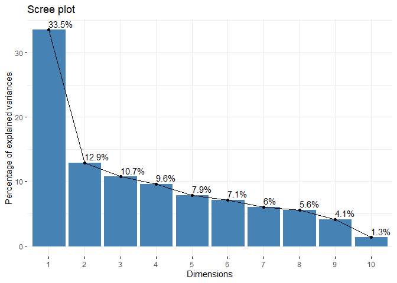

```r
fviz_screeplot(poison_active_mca,addlabel=T)
```

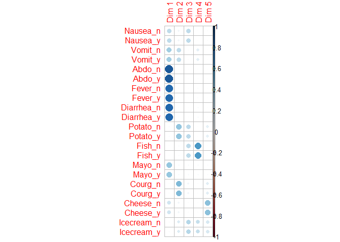

```r
corrplot(poison_active_mca$var$cos2)
```

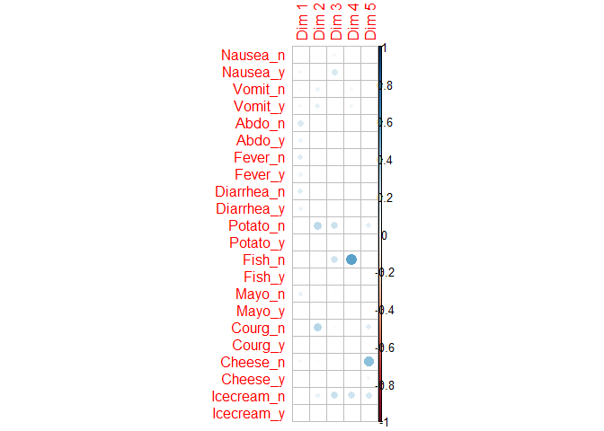

```r
corrplot(poison_active_mca$var$contrib*0.01)
```

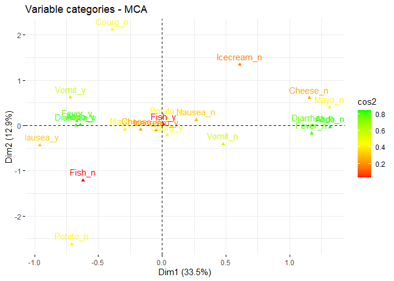

```r
fviz_mca_var(poison_active_mca, repel = F, col.var = "cos2", gradient.cols=c("red", "yellow", "green"))
```

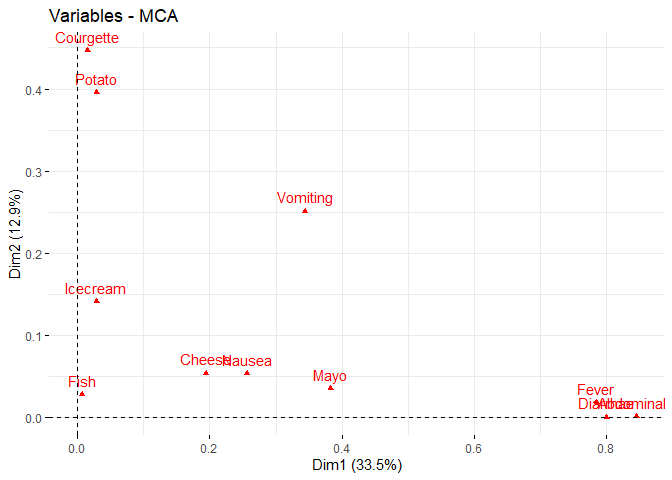

```r
fviz_mca_var(poison_active_mca, repel = F, choice = "mca.cor" )
```

- La componente 1: asocia los sintomas: fiebre, diarrea y dolor abdominal
- componente 2: alimentos

[figure not shown]

```r
fviz_mca_var(poison_active_mca, repel = F, axes = c(1,3),choice = "mca.cor" )
```

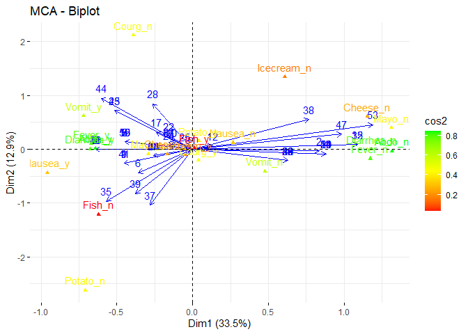

```r
fviz_mca_biplot(poison_active_mca,  col.var = "cos2", gradient.cols=c("red", "yellow", "green"), arrows = c(T,F))
```

Con variables suplementarias

```r
poison_sup_mca=MCA(poison, ind.sup=53:55,
quanti.sup=1:2,
quali.sup=3:4,
graph=F)
```

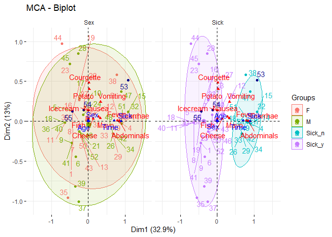

```r
fviz_mca_biplot(poison_sup_mca, repel = T, choice="var", habillage = c(3,4), addEllipses = T )
```

el sexo y la edad no presentan incidencia sobr elos sintomas